# HW8

## Домашнее задание 8. Изучение работы методов контроля температуры в молекулярной динамике.

### Горохов Никита

Начнем с того, что подготовим файл координат и файл топологии.

```python
!wget http://kodomo.fbb.msu.ru/FBB/year_08/term6/etane.gro
```

```
--2019-12-21 22:19:58--  http://kodomo.fbb.msu.ru/FBB/year_08/term6/etane.gro
Resolving kodomo.fbb.msu.ru (kodomo.fbb.msu.ru)... 93.180.63.127
Connecting to kodomo.fbb.msu.ru (kodomo.fbb.msu.ru)|93.180.63.127|:80... connected.
HTTP request sent, awaiting response... 200 OK
Length: 399
Saving to: `etane.gro'

100%[======================================>] 399         --.-K/s   in 0s

2019-12-21 22:19:58 (45.5 MB/s) - `etane.gro' saved [399/399]
```

Построим файл топологии *et.top* для этана. Для этого посмотрим файл *atomtypes.atp*. В нем нас интересуют строчки:

- **opls_139 12.01100 ; alkane C**
- **opls_140 1.00800 ; alkane H.**

```python
!cat /usr/share/gromacs/top/oplsaa.ff/atomtypes.atp
```

[output not shown]

[output cut: 781 more lines]

[output not shown]

Теперь получим информацию о связях и углах

```python
import rdkit
from rdkit import Chem
from rdkit.Chem import AllChem, Draw
from rdkit.Chem import Descriptors
from rdkit import RDConfig
from IPython.display import Image,display
import numpy as np
```

```python
mol=Chem.MolFromSmiles('CC')
AllChem.Compute2DCoords(mol)
m3d=Chem.AddHs(mol)
Chem.AllChem.EmbedMolecule(m3d)
AllChem.MMFFOptimizeMolecule(m3d, maxIters=500, nonBondedThresh=200)
```

```
0
```

```python
# и придумаем циклы
## связи
print "Связи"
bonds = m3d.GetBonds()
for i,b in enumerate(bonds):
    print b.GetBeginAtomIdx() + 1, b.GetEndAtomIdx() + 1, 1

print "\nУглы"
## углы
for b1 in m3d.GetBonds():
    for b2 in m3d.GetBonds():
        if b1.GetBeginAtomIdx() == b2.GetBeginAtomIdx() and b1.GetIdx() != b2.GetIdx():
            print b1.GetEndAtomIdx() + 1, b1.GetBeginAtomIdx() + 1, b2.GetEndAtomIdx() + 1, 1
print "\nДвугранные углы"
## Двугранные углы
for b1 in m3d.GetBonds():
    for b2 in m3d.GetBonds():
        for b3 in m3d.GetBonds():
             if b1.GetBeginAtomIdx() == b2.GetBeginAtomIdx() and b1.GetIdx() != b2.GetIdx() and b2.GetEndAtomIdx() == b3.GetBeginAtomIdx():
                print b1.GetEndAtomIdx() + 1, b1.GetBeginAtomIdx() + 1, b2.GetEndAtomIdx() + 1, b3.GetEndAtomIdx()+1, 3
```

```
Связи
1 2 1
1 3 1
1 4 1
1 5 1
2 6 1
2 7 1
2 8 1

Углы
2 1 3 1
2 1 4 1
2 1 5 1
3 1 2 1
3 1 4 1
```

[output cut: 24 more lines]

Теперь составим файл топологии этана

```python
etan_config = '''
#include "/usr/share/gromacs/top/oplsaa.ff/forcefield.itp"

[ moleculetype ]
; Name            nrexcl
et            3

[ atoms ]
;   nr  type  resnr  residue  atom   cgnr     charge       mass
    1   opls_139      1    ETH      C1      1    -0.189      12.01
    2   opls_139      1    ETH      C2      2    -0.155      12.01
    3   opls_140      1    ETH      H1      3     0.0059       1.008
    4   opls_140      1    ETH      H2      4     0.0059       1.008
    5   opls_140      1    ETH      H3      5     0.0059       1.008
    6   opls_140      1    ETH      H4      6     0.0056       1.008
    7   opls_140      1    ETH      H5      7     0.0056       1.008
    8   opls_140      1    ETH      H6      8     0.0056       1.008

[ bonds ]
;  ai    aj funct  b0       kb
     1   2   1
     1   3   1
     1   4   1
     1   5   1
     2   6   1
     2   7   1
     2   8   1

[ angles ]
;  ai    aj    ak funct  phi0   kphi
;around c1
    3     1     4     1
    4     1     5     1
    3     1     5     1
    2     1     3     1
    2     1     4     1
    2     1     5     1
;around c2
    1     2     6     1
    1     2     7     1
    1     2     8     1
    6     2     7     1
    6     2     8     1
    7     2     8     1


[ dihedrals ]
;  ai    aj    ak    al funct
    3    1     2     6      3
    3    1     2     7      3
    3    1     2     8      3
    4    1     2     6      3
    4    1     2     7      3
    4    1     2     8      3
    5    1     2     6      3
    5    1     2     7      3
    5    1     2     8      3

[ pairs ]
; список атомов 1-4
;  ai    aj funct
   3  6
   3  7
   3  8
   4  6
   4  7
   4  8
   5  6
   5  7
   5  8

[ System ]
; my_system
etan
[ molecules ]
;Name count
 et    1
'''

with open ('et.top','w') as e:
    e.write(etan_config)
```

Скачаем 5 файлов с разными параметрами контроля температуры:

- [метод Берендсена для контроля температуры.](http://kodomo.fbb.msu.ru/FBB/year_08/term6/be.mdp)
- [метод "Velocity rescale" для контроля температуры.](http://kodomo.fbb.msu.ru/FBB/year_08/term6/vr.mdp)
- [метод Нуза-Хувера для контроля температуры.](http://kodomo.fbb.msu.ru/FBB/year_08/term6/nh.mdp)
- [метод Андерсена для контроля температуры.](http://kodomo.fbb.msu.ru/FBB/year_08/term6/an.mdp)
- [метод стохастической молекулярной динамики.](http://kodomo.fbb.msu.ru/FBB/year_08/term6/sd.mdp)

```python
!wget http://kodomo.fbb.msu.ru/FBB/year_08/term6/be.mdp
!wget http://kodomo.fbb.msu.ru/FBB/year_08/term6/vr.mdp
!wget http://kodomo.fbb.msu.ru/FBB/year_08/term6/nh.mdp
!wget http://kodomo.fbb.msu.ru/FBB/year_08/term6/an.mdp
!wget http://kodomo.fbb.msu.ru/FBB/year_08/term6/sd.mdp
```

```
--2019-12-21 21:13:06--  http://kodomo.fbb.msu.ru/FBB/year_08/term6/be.mdp
Resolving kodomo.fbb.msu.ru (kodomo.fbb.msu.ru)... 93.180.63.127
Connecting to kodomo.fbb.msu.ru (kodomo.fbb.msu.ru)|93.180.63.127|:80... connected.
HTTP request sent, awaiting response... 200 OK
Length: 1356 (1.3K)
Saving to: `be.mdp'

100%[======================================>] 1,356       --.-K/s   in 0s

2019-12-21 21:13:06 (184 MB/s) - `be.mdp' saved [1356/1356]

--2019-12-21 21:13:06--  http://kodomo.fbb.msu.ru/FBB/year_08/term6/vr.mdp
Resolving kodomo.fbb.msu.ru (kodomo.fbb.msu.ru)... 93.180.63.127
Connecting to kodomo.fbb.msu.ru (kodomo.fbb.msu.ru)|93.180.63.127|:80... connected.
HTTP request sent, awaiting response... 200 OK
Length: 1427 (1.4K)
Saving to: `vr.mdp'

100%[======================================>] 1,427       --.-K/s   in 0s

2019-12-21 21:13:06 (148 MB/s) - `vr.mdp' saved [1427/1427]

--2019-12-21 21:13:06--  http://kodomo.fbb.msu.ru/FBB/year_08/term6/nh.mdp
Resolving kodomo.fbb.msu.ru (kodomo.fbb.msu.ru)... 93.180.63.127
Connecting to kodomo.fbb.msu.ru (kodomo.fbb.msu.ru)|93.180.63.127|:80... connected.
HTTP request sent, awaiting response... 200 OK
Length: 1429 (1.4K)
Saving to: `nh.mdp'

100%[======================================>] 1,429       --.-K/s   in 0s

2019-12-21 21:13:06 (147 MB/s) - `nh.mdp' saved [1429/1429]

--2019-12-21 21:13:06--  http://kodomo.fbb.msu.ru/FBB/year_08/term6/an.mdp
Resolving kodomo.fbb.msu.ru (kodomo.fbb.msu.ru)... 93.180.63.127
Connecting to kodomo.fbb.msu.ru (kodomo.fbb.msu.ru)|93.180.63.127|:80... connected.
HTTP request sent, awaiting response... 200 OK
Length: 1426 (1.4K)
Saving to: `an.mdp'

100%[======================================>] 1,426       --.-K/s   in 0s

2019-12-21 21:13:06 (175 MB/s) - `an.mdp' saved [1426/1426]

--2019-12-21 21:13:06--  http://kodomo.fbb.msu.ru/FBB/year_08/term6/sd.mdp
Resolving kodomo.fbb.msu.ru (kodomo.fbb.msu.ru)... 93.180.63.127
Connecting to kodomo.fbb.msu.ru (kodomo.fbb.msu.ru)|93.180.63.127|:80... connected.
HTTP request sent, awaiting response... 200 OK
Length: 1441 (1.4K)
Saving to: `sd.mdp'

100%[======================================>] 1,441       --.-K/s   in 0s

2019-12-21 21:13:06 (168 MB/s) - `sd.mdp' saved [1441/1441]
```

```python
import subprocess

methods = ["be", "vr", "nh", "an", "sd"]
```

Построим входные файлы для молекулярно-динамического движка *mdrun* с помощью *grompp*

```python
for method in methods:
    cmd = "grompp -f %s.mdp -c etane.gro -p et.top -o et_%s.tpr" % (method, method)
    subprocess.call(cmd, shell=True)
```

Получилось 5 tpr файлов. Теперь для каждого из них запустим *mdrun*.

```python
for method in methods:
    cmd = "mdrun -deffnm et_%s -v -nt 1" % (method)
    subprocess.call(cmd, shell=True)
```

Теперь переходим к анализу результатов. Начнем с визуального анализа. Для каждой из 5 систем проведем конвертацию в pdb и отобразим в PyMol.

```python
for method in methods:
    cmd = "echo 0 | trjconv -f et_%s.trr -s et_%s.tpr -o et_%s.pdb" % (method, method, method)
    subprocess.call(cmd, shell=True)
```

Я локально сохранил полученные видео.  
К сожалению, не получилось визуализировать с помощью IPython.display.Video  
Поэтому возпользуемся HTML

```python
from IPython.display import HTML

#  ["be", "vr", "nh", "an", "sd"]
names = ["метод Берендсена",
         'метод "Velocity rescale"',
         "метод Нуза-Хувера",
         "метод Андерсена",
         "метод стохастической молекулярной динамики"
]

for (i, method) in enumerate(methods):
    display(HTML("""
        <h2>
            %s
        </h2>
        <video alt="test" controls>
            <source src="HW8-video/%s.mp4" type="video/mp4">
        </video>
        """ % (names[i], method)))
```

метод Берендсена

[video not shown]

метод "Velocity rescale"

[video not shown]

метод Нуза-Хувера

[video not shown]

метод Андерсена

[video not shown]

метод стохастической молекулярной динамики

[video not shown]

Сравним потенциальную энергию и кинетическую энергию для каждой из 5 систем.  
Для этого воспользуемся командой *g_energy*

```python
for method in methods:
    cmd = 'echo 10 | g_energy -f et_%s.edr -o potential_energy_et_%s.xvg -xvg none' % (method, method)
    subprocess.call(cmd, shell=True)

for method in methods:
    cmd = 'echo 11 | g_energy -f et_%s.edr -o kinetic_energy_et_%s.xvg -xvg none' % (method, method)
    subprocess.call(cmd, shell=True)
```

Построим графики изменения энергий

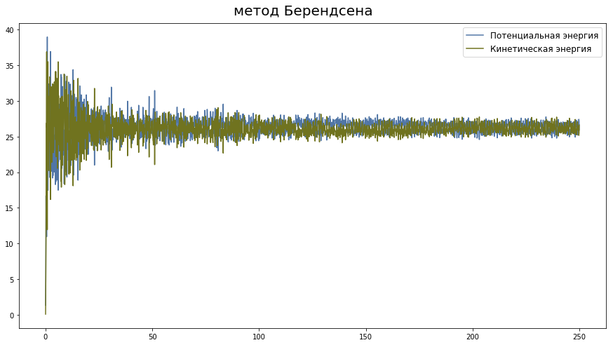

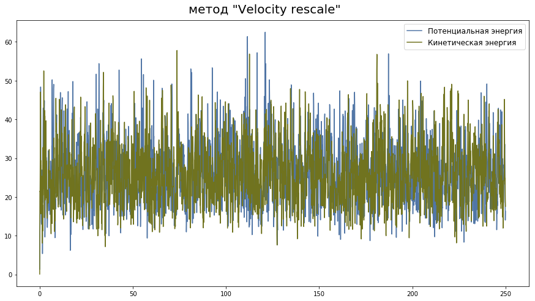

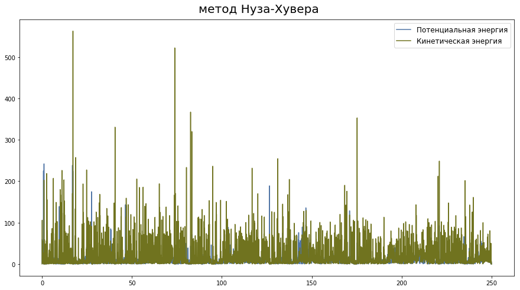

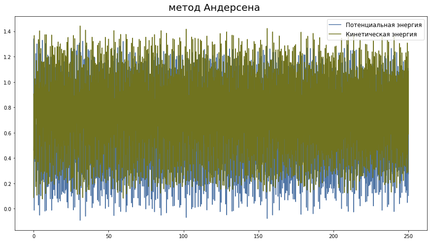

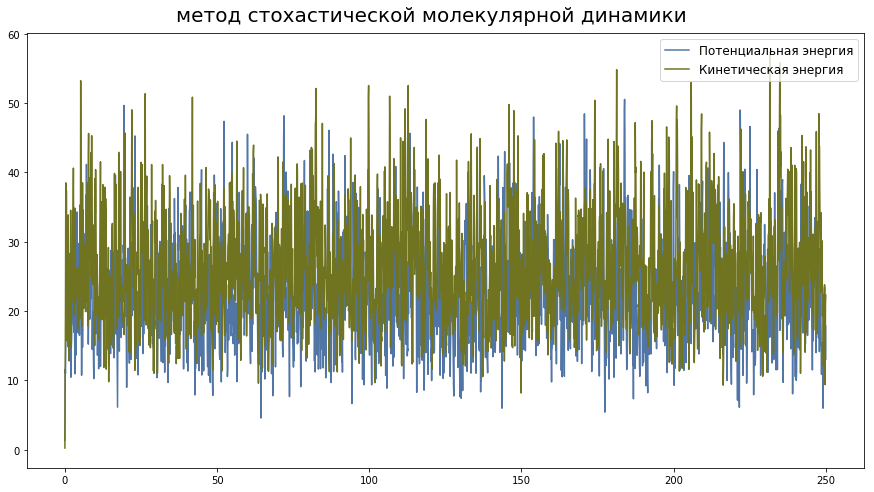

```python
import matplotlib.pyplot as plt
import numpy as np

for (i, method) in enumerate(methods):
    fig = plt.figure(figsize=(15, 8))
    potential_energy= np.loadtxt('potential_energy_et_%s.xvg' % method)
    kinetic_energy = np.loadtxt('kinetic_energy_et_%s.xvg' % method)
    t = potential_energy[:,0]
    plt.plot(t, potential_energy[:, 1], color='#5176A6', label='Потенциальная энергия'.decode('utf8'))
    plt.plot(t, kinetic_energy[:, 1], color='#70731F', label='Кинетическая энергия'.decode('utf8'))
    plt.figtext(.5, .9, names[i].decode('utf8'), fontsize=20, ha='center')
    plt.legend(loc=1, prop={'size': 12})
    plt.show()
```

**метод Берендсена** дает распределение, похожее на расрпделение *Больцмана*

Рассмотрим распределение длинны связи С-С за время моделирования. Сначала создадим индекс файл с одной связью. В текстовом редакторе создадим файл **b.ndx** со следующим содержимым:  
[ b ]  
1 2

```python
f = '''
[ b ]
1 2
'''

with open ('b.ndx','w') as e:
    e.write(f)
```

И запустим утилиту по анализу связей *g_bond*

```python
for method in methods:
    cmd = 'g_bond -f et_%s.trr -s et_%s.tpr -o bond_%s.xvg -n b.ndx -xvg none' % (method, method, method)
    subprocess.call(cmd, shell=True)
```

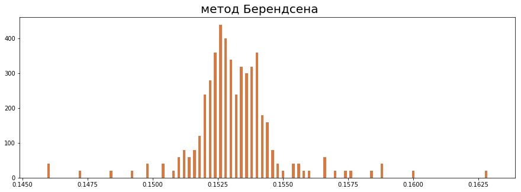

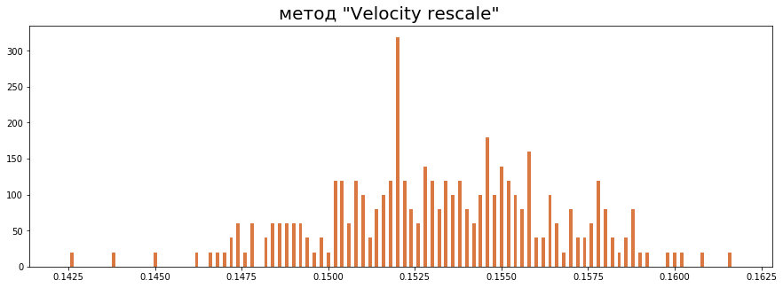

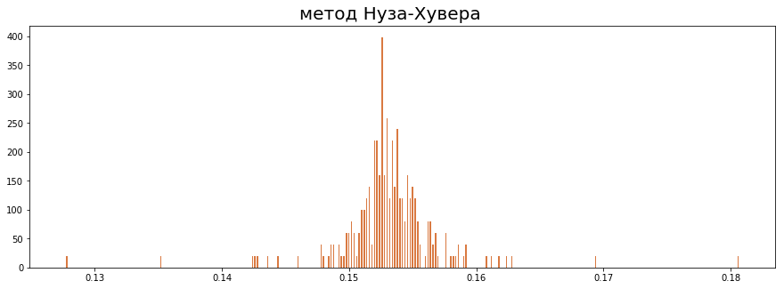

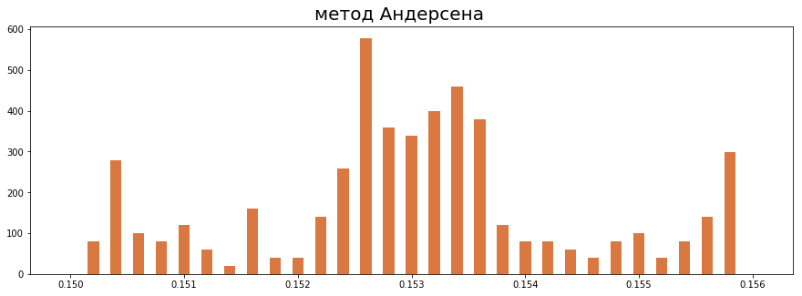

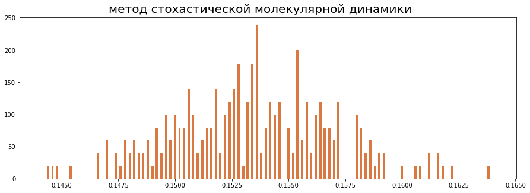

```python
for (i, method) in enumerate(methods):
    fig = plt.figure(figsize=(15, 5))
    bond = np.loadtxt('bond_%s.xvg' % method)
    scale = (bond[1, 0] - bond[0, 0]) / 2
    plt.bar(bond[:, 0], bond[:, 1], width = scale, color = "#D97941")
    plt.figtext(.5, .9, names[i].decode('utf8'), fontsize=20, ha='center')
    plt.show()
```

Учитывая форму распределения Больцмана и все Ваши наблюдения сделайте вывод о том какой из методов позволяет наиболее реалистично поддерживать температуру в системе. Опишите найденные Вами недостатки предложенных алгоритмов. Постройте таблицу зависимости быстродействия от алгоритма.  
Повторно запустим **mdrun**, для того, чтобы узнать время работы

```python
import time
import pandas as pd

method_times = []

for method in methods:
    start_time = time.time()
    cmd = "mdrun -deffnm et_%s -v -nt 1" % (method)
    subprocess.call(cmd, shell=True)
    end_time = time.time()
    method_times.append(end_time - start_time)

df = pd.DataFrame(
    {
        "метод": names,
        "время, сек": method_times
    })
df
```

|  | время, сек | метод |
| --- | --- | --- |
| 0 | 4.939685 | метод Берендсена |
| 1 | 5.000972 | метод "Velocity rescale" |
| 2 | 5.052264 | метод Нуза-Хувера |
| 3 | 4.785966 | метод Андерсена |
| 4 | 6.185364 | метод стохастической молекулярной динамики |

**ВЫВОД**: так как *метод Берендсена* дает график, похожий на распределение Больцмана, то значит этот метод позволяет наиболее реалистично поддерживать температуру в системе.